# Strategies to prevent overfitting in neural networks

```python
%matplotlib inline

import numpy as np
import pandas as pd
import tensorflow as tf
import matplotlib.pyplot as plt
import seaborn as sns

from sklearn.model_selection import train_test_split
from sklearn.metrics import accuracy_score
from sklearn.metrics import multilabel_confusion_matrix
from sklearn.metrics import classification_report

from tensorflow.keras import regularizers
from tensorflow.keras.preprocessing.text import Tokenizer
from tensorflow.keras.preprocessing.sequence import pad_sequences
from tensorflow.keras.layers import Embedding, Dense, GlobalMaxPooling1D, Dropout
from tensorflow.keras.models import Sequential
from tensorflow.keras import regularizers
from tensorflow.keras.callbacks import EarlyStopping

from sklearn.model_selection import GridSearchCV
from keras.wrappers.scikit_learn import KerasClassifier


try:
    tf.set_random_seed(1337)                    # set the random seed for reproducibility
except:
    tf.random.set_seed(1337)                     # NOTE: Newer version of tensorflow uses tf.random.set_seed
np.random.seed(1337)                         #       instead of tf.set_random_seed
```

## Introduction

**Business Context.** You are a data scientist working for a machine learning consultancy. One of your clients wants to be able to classify text reviews automatically by the likely rating (on a 1 - 5 scale) that that person would give. However, they do not have sufficient data they generated on their own to do this, so you need to use an external, rich dataset as a basis on which to build your model and then translate it over.

**Business Problem.** Your task is to **build a neural networks-based model for classifying text reviews into likely ratings (on a 1 - 5 scale)**.

**Analytical Context.** We'll use the Amazon review dataset again and try to classify reviews into star ratings automatically. Instead of just positive and negative, we'll take on the harder challenge of predicting the *exact* star rating. The lowest score is 1 and the highest is 5.

Instead of trying to optimize by pre-processing the text, we'll do very basic tokenization and experiment with different neural network models, architectures, and hyperparameters to optimize the results. You'll start by building a simple dense neural network and try to get it to perform better using various techniques. Then you'll evaluate the results and diagnose where it tends to perform more poorly.

## Setting up and preparing the data

We'll mainly be using the `keras` module from TensorFlow, but we'll also use `pandas` to read the CSV file and `sklearn` for some helper functions. We'll be using only the "Text" and "Score" columns in the `Reviews.csv` file:

```python
amazon_reviews = pd.read_csv('https://bootcamp-04.s3.us-east-2.amazonaws.com/Reviews.csv', nrows=262084)
amazon_reviews.head(5)
```

|  | Id | ProductId | UserId | ProfileName | HelpfulnessNumerator | HelpfulnessDenominator | Score | Time | Summary | Text |
| --- | --- | --- | --- | --- | --- | --- | --- | --- | --- | --- |
| 0 | 1 | B001E4KFG0 | A3SGXH7AUHU8GW | delmartian | 1 | 1 | 5 | 1303862400 | Good Quality Dog Food | I have bought several of the Vitality canned d... |
| 1 | 2 | B00813GRG4 | A1D87F6ZCVE5NK | dll pa | 0 | 0 | 1 | 1346976000 | Not as Advertised | Product arrived labeled as Jumbo Salted Peanut... |
| 2 | 3 | B000LQOCH0 | ABXLMWJIXXAIN | Natalia Corres "Natalia Corres" | 1 | 1 | 4 | 1219017600 | "Delight" says it all | This is a confection that has been around a fe... |
| 3 | 4 | B000UA0QIQ | A395BORC6FGVXV | Karl | 3 | 3 | 2 | 1307923200 | Cough Medicine | If you are looking for the secret ingredient i... |
| 4 | 5 | B006K2ZZ7K | A1UQRSCLF8GW1T | Michael D. Bigham "M. Wassir" | 0 | 0 | 5 | 1350777600 | Great taffy | Great taffy at a great price. There was a wid... |

### Exercise 1:

Combine the first 1,000 of each of the 1-, 2-, 3-, 4-, and 5-star reviews in `amazon_reviews` into a single DataFrame (so you should have 5,000 observations in total). Split this DataFrame into training and test sets, with 80% of the data for the training set.

**Hint:** `keras` will expected your labels to start with 0, and not 1, so make sure to adjust the labels accordingly.

**Answer.**

```python
ama_rev_balanced = pd.concat([amazon_reviews.query('Score=={}'.format(i)).head(1000) for i in [1,2,3,4,5]]).reset_index(drop=True)
# This dataset contains 5000 observations
```

```python
ama_rev_train, ama_rev_test = train_test_split(ama_rev_balanced, test_size=0.20, random_state=2020)
# ama_rev_train contains 4000 rows, and ama_rev_test contains 1000 rows
# Both datasets contains a balanced proportion of scores
```

```python
ama_rev_train['Score'].value_counts()*100/ ama_rev_train.shape[0]
```

```
4    20.550
1    20.500
3    19.975
2    19.500
5    19.475
Name: Score, dtype: float64
```

```python
ama_rev_test['Score'].value_counts()*100/ ama_rev_test.shape[0]
```

```
5    22.1
2    22.0
3    20.1
1    18.0
4    17.8
Name: Score, dtype: float64
```

## Tokenizing our texts

Keras comes with its own functions to preprocess text, including a [tokenizer](https://www.tensorflow.org/api_docs/python/tf/keras/preprocessing/text/Tokenizer) (a mapping from each word in our corpus to a unique integer). Unlike the `CountVectorizer` from `sklearn`, which produces sparse matrices, `keras` often expects to work with sequences representing only the words that occur in a text. To prepare text before feeding it into a neural network, we usually:

1. Create a [tokenizer](https://www.tensorflow.org/api_docs/python/tf/keras/preprocessing/text/Tokenizer).
2. [Create sequences](https://www.tensorflow.org/api_docs/python/tf/keras/preprocessing/text/Tokenizer#texts_to_sequences) from our text (each text becomes a list of integers, based on the tokenizer mapping, instead of words)
3. [Pad or truncate](https://www.tensorflow.org/api_docs/python/tf/keras/preprocessing/sequence/pad_sequences) each sequence to a fixed length (very short texts get `0`s added to them, while very long ones are truncated).

The tokenizer has a configurable word cap, so it will only consider the $n$ most common words in the corpus, ignoring very rare words.

### Exercise 2:

In this exercise, you will learn how to use the `tf.keras.preprocessing.text.Tokenizer` tool to carry out the preprocessing steps described above.

#### 2.1

Perform some exploratory analysis of the dataset to calculate the number of unique words in our corpus and the distribution of the number of words in each review of the training set. What is the 80th percentile of this distribution?

**Answer.**

```python
import nltk
nltk.download('punkt')
```

```
True
```

```python
tokens = [k for i in ama_rev_test['Text'].apply(lambda x: nltk.word_tokenize(x)) for k in i]
print("N. of words in test set:\t{:}".format( len(set(tokens)) ))
tokens = [k for i in ama_rev_train['Text'].apply(lambda x: nltk.word_tokenize(x)) for k in i]
print("N. of words in training set:\t{:}".format( len(set(tokens)) ))
```

```
N. of words in test set:	9010
N. of words in training set:	18749
```

```python
ama_rev_train = ama_rev_train.assign(
    nChars=lambda df:df.Text.apply(lambda x: len(x)),
    nWords=lambda df:df.Text.apply(lambda x: len(nltk.word_tokenize(x))),
    nSents=lambda df:df.Text.apply(lambda x: len(nltk.sent_tokenize(x)))
)
ama_rev_test = ama_rev_test.assign(
    nChars=lambda df:df.Text.apply(lambda x: len(x)),
    nWords=lambda df:df.Text.apply(lambda x: len(nltk.word_tokenize(x))),
    nSents=lambda df:df.Text.apply(lambda x: len(nltk.sent_tokenize(x)))
)
```

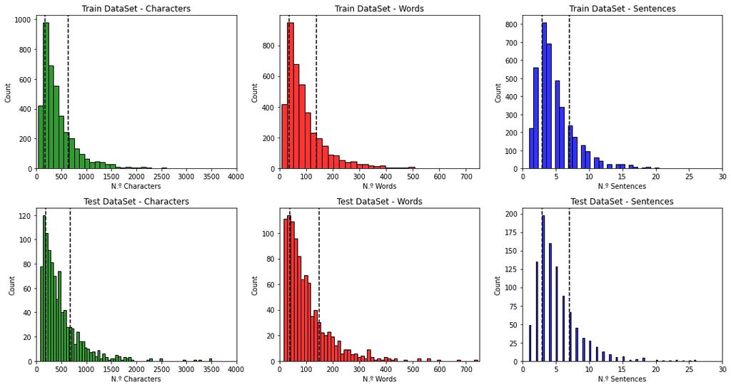

```python
fig, ax = plt.subplots(2,3, figsize=(15,8))

def plotCountComponents(data, var, ax : int, color, xlab='', main='', xlim=(0,0)):
  sns.histplot(data[var], linewidth=1, alpha = 0.8, color=color, ax=ax, bins=100)
  ax.axvline(data[var].quantile([0.2, 0.8]).iloc[0], ls='--',color = 'black')
  ax.axvline(data[var].quantile([0.2, 0.8]).iloc[1], ls='--',color = 'black')
  ax.set(title=main, xlabel=xlab, xlim=xlim)

plotCountComponents(ama_rev_train, 'nChars', ax[0][0], 'g', 'N.º Characters', 'Train DataSet - Characters', (0,4000))
plotCountComponents(ama_rev_train, 'nWords', ax[0][1], 'r', 'N.º Words',      'Train DataSet - Words', (0,750))
plotCountComponents(ama_rev_train, 'nSents', ax[0][2], 'b', 'N.º Sentences',  'Train DataSet - Sentences', (0,30))

plotCountComponents(ama_rev_test, 'nChars', ax[1][0], 'g', 'N.º Characters',  'Test DataSet - Characters', (0,4000))
plotCountComponents(ama_rev_test, 'nWords', ax[1][1], 'r', 'N.º Words',       'Test DataSet - Words', (0,750))
plotCountComponents(ama_rev_test, 'nSents', ax[1][2], 'b', 'N.º Sentences',   'Test DataSet - Sentences', (0,30))
fig.set_tight_layout(True)
```

```python
print('Train Data, 80th percentile - number of Words \t {:.2f}'.format(ama_rev_train['nWords'].quantile(0.8)))
print('Test Data, 80th percentile - number of Words \t {:.2f}'.format(ama_rev_test['nWords'].quantile(0.8)))
```

```
Train Data, 80th percentile - number of Words 	 140.00
Test Data, 80th percentile - number of Words 	 150.20
```

```python
import string
from nltk.util import ngrams
from collections import Counter
from nltk.corpus import stopwords
nltk.download('stopwords')
stop_words = set(stopwords.words("english"))
```

```python
def columnwithNgrams(data, n, k, notWords = None, qr='Score!=10'):
  stopWords1 = list(stop_words); stopWords1.extend(notWords)
  df = data.query(qr)
  du = df['Text'].apply(lambda x: nltk.word_tokenize(x))
  du = map(lambda x: [i for i in x if i.lower() not in stopWords1], du)
  du = map(lambda x: [i for i in x if i not in string.punctuation], du)
  du = map(lambda x: [" ".join(i) for i in ngrams(x, n)], du)

  most_common_k = Counter([i for j in du for i in j]).most_common(k)
  most_common_DF = pd.DataFrame({'Gram': dict(most_common_k).keys(),
                                 'Count':map(int, dict(most_common_k).values())})

  return most_common_DF
```

```python
notDesirableWords = ['br', "href=", "n't", "'ve", 'http', "'m", "'s", "''", "``", "...", "---"]
```

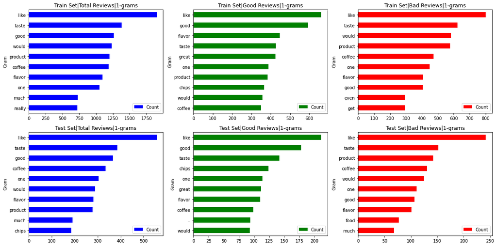

```python
fig, ax = plt.subplots(2,3, figsize=(16,8))

d = columnwithNgrams(ama_rev_train, 1, 10, notDesirableWords)
d.sort_values('Count').plot.barh(x='Gram', y='Count', color='blue', ax=ax[0][0])
d = columnwithNgrams(ama_rev_train, 1, 10, notDesirableWords, 'Score > 3')
d.sort_values('Count').plot.barh(x='Gram', y='Count', color='green', ax=ax[0][1])
d = columnwithNgrams(ama_rev_train, 1, 10, notDesirableWords, 'Score < 3')
d.sort_values('Count').plot.barh(x='Gram', y='Count', color='red', ax=ax[0][2])
#
d = columnwithNgrams(ama_rev_test, 1, 10, notDesirableWords)
d.sort_values('Count').plot.barh(x='Gram', y='Count', color='blue', ax=ax[1][0])
d = columnwithNgrams(ama_rev_test, 1, 10, notDesirableWords, 'Score > 3')
d.sort_values('Count').plot.barh(x='Gram', y='Count', color='green', ax=ax[1][1])
d = columnwithNgrams(ama_rev_test, 1, 10, notDesirableWords, 'Score < 3')
d.sort_values('Count').plot.barh(x='Gram', y='Count', color='red', ax=ax[1][2])
#
ax[0][0].set(title = 'Train Set|Total Reviews|1-grams')
ax[0][1].set(title = 'Train Set|Good Reviews|1-grams')
ax[0][2].set(title = 'Train Set|Bad Reviews|1-grams')
ax[1][0].set(title = 'Test Set|Total Reviews|1-grams')
ax[1][1].set(title = 'Test Set|Good Reviews|1-grams')
ax[1][2].set(title = 'Test Set|Bad Reviews|1-grams')

fig.set_tight_layout(True)
```

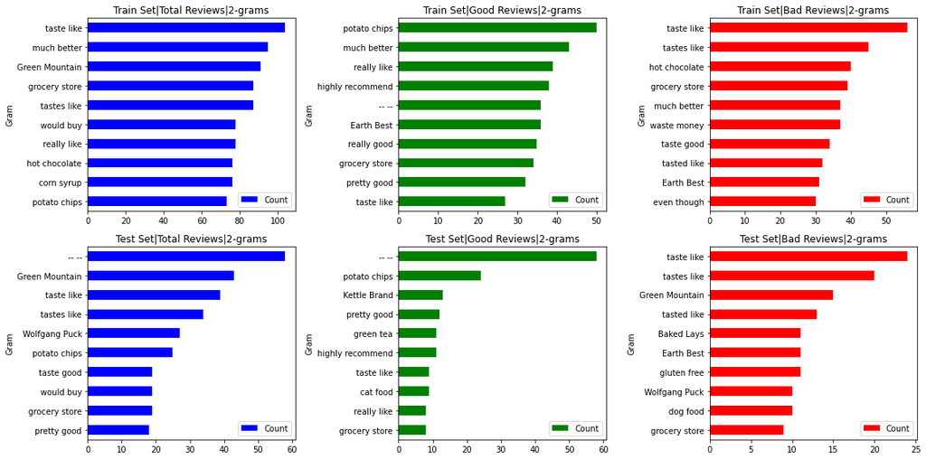

```python
fig, ax = plt.subplots(2,3, figsize=(16,8))

d = columnwithNgrams(ama_rev_train, 2, 10, notDesirableWords)
d.sort_values('Count').plot.barh(x='Gram', y='Count', color='blue', ax=ax[0][0])
d = columnwithNgrams(ama_rev_train, 2, 10, notDesirableWords, 'Score > 3')
d.sort_values('Count').plot.barh(x='Gram', y='Count', color='green', ax=ax[0][1])
d = columnwithNgrams(ama_rev_train, 2, 10, notDesirableWords, 'Score < 3')
d.sort_values('Count').plot.barh(x='Gram', y='Count', color='red', ax=ax[0][2])
#
d = columnwithNgrams(ama_rev_test, 2, 10, notDesirableWords)
d.sort_values('Count').plot.barh(x='Gram', y='Count', color='blue', ax=ax[1][0])
d = columnwithNgrams(ama_rev_test, 2, 10, notDesirableWords, 'Score > 3')
d.sort_values('Count').plot.barh(x='Gram', y='Count', color='green', ax=ax[1][1])
d = columnwithNgrams(ama_rev_test, 2, 10, notDesirableWords, 'Score < 3')
d.sort_values('Count').plot.barh(x='Gram', y='Count', color='red', ax=ax[1][2])
#
ax[0][0].set(title = 'Train Set|Total Reviews|2-grams')
ax[0][1].set(title = 'Train Set|Good Reviews|2-grams')
ax[0][2].set(title = 'Train Set|Bad Reviews|2-grams')
ax[1][0].set(title = 'Test Set|Total Reviews|2-grams')
ax[1][1].set(title = 'Test Set|Good Reviews|2-grams')
ax[1][2].set(title = 'Test Set|Bad Reviews|2-grams')

fig.set_tight_layout(True)
```

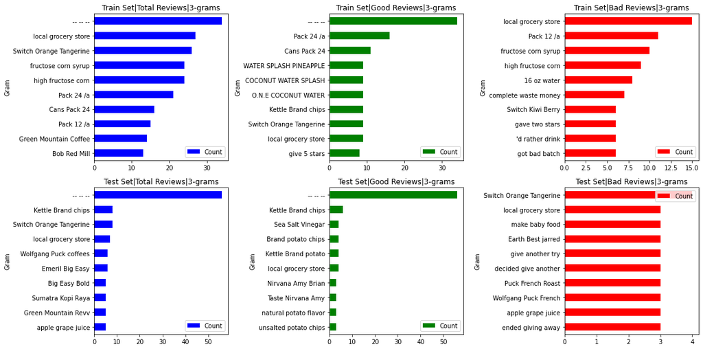

```python
fig, ax = plt.subplots(2,3, figsize=(16,8))

d = columnwithNgrams(ama_rev_train, 3, 10, notDesirableWords)
d.sort_values('Count').plot.barh(x='Gram', y='Count', color='blue', ax=ax[0][0])
d = columnwithNgrams(ama_rev_train, 3, 10, notDesirableWords, 'Score > 3')
d.sort_values('Count').plot.barh(x='Gram', y='Count', color='green', ax=ax[0][1])
d = columnwithNgrams(ama_rev_train, 3, 10, notDesirableWords, 'Score < 3')
d.sort_values('Count').plot.barh(x='Gram', y='Count', color='red', ax=ax[0][2])
#
d = columnwithNgrams(ama_rev_test, 3, 10, notDesirableWords)
d.sort_values('Count').plot.barh(x='Gram', y='Count', color='blue', ax=ax[1][0])
d = columnwithNgrams(ama_rev_test, 3, 10, notDesirableWords, 'Score > 3')
d.sort_values('Count').plot.barh(x='Gram', y='Count', color='green', ax=ax[1][1])
d = columnwithNgrams(ama_rev_test, 3, 10, notDesirableWords, 'Score < 3')
d.sort_values('Count').plot.barh(x='Gram', y='Count', color='red', ax=ax[1][2])
#
ax[0][0].set(title = 'Train Set|Total Reviews|3-grams')
ax[0][1].set(title = 'Train Set|Good Reviews|3-grams')
ax[0][2].set(title = 'Train Set|Bad Reviews|3-grams')
ax[1][0].set(title = 'Test Set|Total Reviews|3-grams')
ax[1][1].set(title = 'Test Set|Good Reviews|3-grams')
ax[1][2].set(title = 'Test Set|Bad Reviews|3-grams')

fig.set_tight_layout(True)
```

#### 2.2

```python
tokenizer = Tokenizer(num_words=20000) #We create the tokenizer using only top 20000 words
```

```python
tokenizer.fit_on_texts(ama_rev_train['Text'])  #Then, we create the text->indices mapping.
```

The above line has given several features and methods to our tokenizer. For instance, print the line `tokenizer.word_index` in a new cell - what do you see? Apply the `tokenizer.texts_to_sequences()` method on the list `['I just feel very very good']`. Apply the `tokenizer.sequences_to_texts()` method on the list `[[109, 19, 824, 76, 114, 6315, 1137, 8070]]`. What were your results?

**Answer.**

```python
pd.DataFrame({'Word':[i for i in tokenizer.word_index],
              'Value':[i for i in tokenizer.word_index.values()]})
```

|  | Word | Value |
| --- | --- | --- |
| 0 | the | 1 |
| 1 | i | 2 |
| 2 | a | 3 |
| 3 | and | 4 |
| 4 | to | 5 |
| ... | ... | ... |
| 13277 | hip | 13278 |
| 13278 | maximizing | 13279 |
| 13279 | textured | 13280 |
| 13280 | orac | 13281 |
| 13281 | dementia | 13282 |

13282 rows × 2 columns

The `Tokenizer` object allows you to create a list with an identification of each word with a unique identification number.

```python
tokenizer.texts_to_sequences(["Mr Stark i don't feel so good"])
```

```
[[2763, 2, 63, 349, 26, 32]]
```

The `texts_to_sequences` method generates a vector with the identification code of each word. If the word does not exist within `Tokenizer` it is omitted when generating the numeric vector.

```python
tokenizer.sequences_to_texts([[109, 19, 824, 76, 114, 6315, 1137, 8070]])
```

```
['then you paying what still partner style hay']
```

#### 2.3

**Answer.**

```python
# train_sequences = ama_rev_train['Text'].apply(lambda x: pad_sequences(tokenizer.texts_to_sequences(x), maxlen=116))
# test_sequences  = ama_rev_test['Text'].apply(lambda x: pad_sequences(tokenizer.texts_to_sequences(x), maxlen=116))

train_sequences = pad_sequences(tokenizer.texts_to_sequences(ama_rev_train['Text']), maxlen=116)
test_sequences  = pad_sequences(tokenizer.texts_to_sequences(ama_rev_test['Text']), maxlen=116)
```

## Building a basic neural network model

Now that we have preprocessed the text, let's create a basic neural network to train on our data. We'll use an embedding layer which performs [one-hot encoding](https://machinelearningmastery.com/why-one-hot-encode-data-in-machine-learning/) on our word sequences, two fully connected ("dense") layers, and an output layer with 5 neurons to represent the 5 possible star ratings.

Before we train a `keras` model, there is an additional `compile` step where we define what loss function and optimizer to use, and what metrics to output. Then we can train the model using the `fit` function. All of this is shown below.

Note the `validation_split=0.2` argument which tells Keras to train on only 80% of the training data and tune the model on the remaining 20%, which we call the validation set. You can see the accuracy and loss for both the training and validation set in the output for each epoch:

```python
model = Sequential()
model.add(Embedding(20000, 128, input_length=116))
model.add(Dense(128, activation='relu'))
model.add(Dense(128, activation='relu'))
model.add(GlobalMaxPooling1D())
model.add(Dense(5, activation='sigmoid'))
model.compile(loss='sparse_categorical_crossentropy', optimizer='adam', metrics=['accuracy'])
```

```python
model.summary()
```

```
Model: "sequential_1"
_________________________________________________________________
Layer (type)                 Output Shape              Param #
=================================================================
embedding_1 (Embedding)      (None, 116, 128)          2560000
_________________________________________________________________
dense_3 (Dense)              (None, 116, 128)          16512
_________________________________________________________________
dense_4 (Dense)              (None, 116, 128)          16512
_________________________________________________________________
global_max_pooling1d_1 (Glob (None, 128)               0
_________________________________________________________________
dense_5 (Dense)              (None, 5)                 645
=================================================================
Total params: 2,593,669
Trainable params: 2,593,669
Non-trainable params: 0
_________________________________________________________________
```

```python
train_labels = ama_rev_train['Score'].map(lambda x: x-1).to_numpy().astype(np.float32)
test_labels  = ama_rev_test['Score'].map(lambda x: x-1).to_numpy().astype(np.float32)
train_labels
```

```
array([3., 4., 2., ..., 3., 4., 0.], dtype=float32)
```

```python
model.fit(train_sequences, train_labels, validation_split=0.2, epochs=10,
          validation_data=(test_sequences, test_labels))
```

```
<tensorflow.python.keras.callbacks.History at 0x7f6730cc83c8>
```

### Exercise 3:

How well does this model perform? How does this compare to a baseline expectation? What do you notice about the accuracy and loss values for both the validation and training sets over time and what does this mean?

**Answer.**

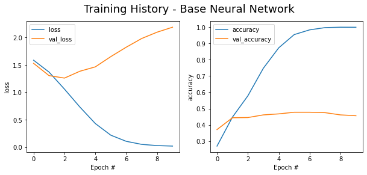

```python
def trainingHistoryPlot(model, title = 'Training History'):
  d = pd.DataFrame(model.history.history).reset_index()
  fig, ax = plt.subplots(1,2,figsize=(10,4))
  sns.lineplot(x = 'index', y = 'loss', data=d, label='loss', ax=ax[0])
  sns.lineplot(x = 'index', y = 'val_loss', data=d, label='val_loss', ax=ax[0])
  sns.lineplot(x = 'index', y = 'accuracy', data=d, label='accuracy', ax=ax[1])
  sns.lineplot(x = 'index', y = 'val_accuracy', data=d, label='val_accuracy', ax=ax[1]);
  ax[0].set(xlabel='Epoch #'); ax[1].set(xlabel='Epoch #');
  fig.suptitle(title, fontsize=18);
  return

trainingHistoryPlot(model, 'Training History - Base Neural Network')
```

```python
pred_train_labels = np.fromiter(map(lambda x: np.argmax(x), model.predict(train_sequences)), dtype='float32')
pred_test_labels  = np.fromiter(map(lambda x: np.argmax(x), model.predict(test_sequences)), dtype='float32')

print('-'*70)
print('Train Data'*1)
print("Accuracy: {:.1f}%".format(
    accuracy_score(train_labels, pred_train_labels)*100
))
#
print('-'*70)
print(classification_report(train_labels + 1, pred_train_labels + 1))
#
print('-'*70)
print('Test Data'*1)
print("Accuracy: {:.1f}%".format(
    accuracy_score(test_labels, pred_test_labels)*100
))
#
print('-'*70)
print(classification_report(test_labels + 1, pred_test_labels + 1))
```

```
----------------------------------------------------------------------
Train Data
Accuracy: 89.0%
----------------------------------------------------------------------
              precision    recall  f1-score   support

         1.0       0.90      0.90      0.90       820
         2.0       0.86      0.89      0.88       780
         3.0       0.90      0.86      0.88       799
         4.0       0.88      0.89      0.88       822
         5.0       0.92      0.91      0.91       779

    accuracy                           0.89      4000
   macro avg       0.89      0.89      0.89      4000
weighted avg       0.89      0.89      0.89      4000

----------------------------------------------------------------------
Test Data
Accuracy: 43.1%
----------------------------------------------------------------------
              precision    recall  f1-score   support

         1.0       0.45      0.51      0.48       180
         2.0       0.43      0.41      0.42       220
         3.0       0.33      0.30      0.32       201
         4.0       0.35      0.44      0.39       178
         5.0       0.63      0.50      0.56       221

    accuracy                           0.43      1000
   macro avg       0.44      0.43      0.43      1000
weighted avg       0.44      0.43      0.43      1000
```

```python
def confusion(ytest, y_pred, title=''):
    names=["Positive","Negative"]
    cm = multilabel_confusion_matrix(ytest, y_pred)
    fig, ax = plt.subplots(1, 5, figsize=(15,3))
    # ax = ax.ravel()
    for i, mat in enumerate(cm):
      mat1 = mat/np.sum(mat)
      mat_rav = mat.ravel()

      sns.heatmap(mat1, fmt='.1%', annot=True, linewidth=.5, linecolor="black", cmap = 'Blues', ax=ax[i], cbar=False, vmin=0, vmax=1)
      ax[i].set(xlabel=r"$\mathrm{y_{pred}}$", ylabel=r"$\mathrm{y_{true}}$")
      ax[i].set(title = "Score {}".format(i+1))
      ax[i].set_xticklabels(names); ax[i].set_yticklabels(names)
      for r, t in zip(mat_rav, ax[i].texts): t.set_text(t.get_text() + "\n({})".format(r))

    fig.set_tight_layout(True)
    fig.suptitle(title, fontsize=15, verticalalignment='bottom')

    plt.show()
    return
```

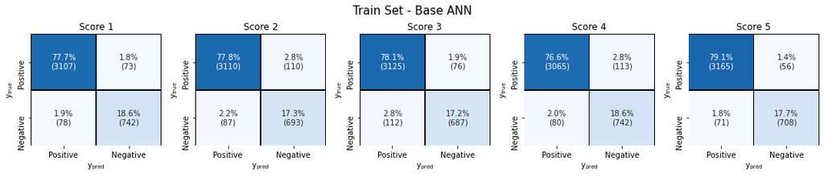

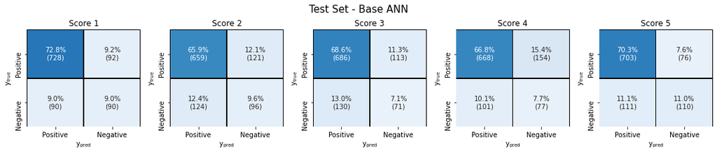

```python
confusion(train_labels, pred_train_labels, 'Train Set - Base ANN')
confusion(test_labels,  pred_test_labels,  'Test Set - Base ANN')
```

The results of these metrics suggest that the model is overfitted. The precision of the training set is much higher than that presented for the test data for all scores.

## Experimenting with different regularization strategies

There are many different ways to mitigate overfitting in a neural network, collectively known as *regularization* techniques. One common regularization technique is called Dropout. In this regularization method, a set of neurons is randomly selected at each training step to be completely ignored. This is done so that the neurons in our network do not rely strongly on their neighboring neurons and we avoid the creation of ["co-adaptations"](http://jmlr.org/papers/volume15/srivastava14a/srivastava14a.pdf) that do not generalize well to unseen data. This making the model more robust and less prone to overffiting.

You can create dropouts in `keras` by adding a layer named `Dropout(p)`, where `p` is the probability of dropping neurons in the previous layer. For example, the following model would implement dropout by removing roughly 20% percent of the outputs of the embedding layer at each training step:

```python
model2 = Sequential()
model2.add(Embedding(20000, 128, input_length=116))
model2.add(Dropout(0.2)) # --------------------------->Dropout layer will affect the output of previous layer.
model2.add(Dense(128, activation='relu'))
model2.add(Dense(128, activation='relu'))
model2.add(GlobalMaxPooling1D())
model2.add(Dense(5, activation='sigmoid'))
model2.compile(loss='sparse_categorical_crossentropy', optimizer='adam', metrics=['accuracy'])
model2.fit(train_sequences, train_labels, validation_split=0.2, epochs=10,
          validation_data=(test_sequences, test_labels))
```

```
<tensorflow.python.keras.callbacks.History at 0x7fb75fd6def0>
```

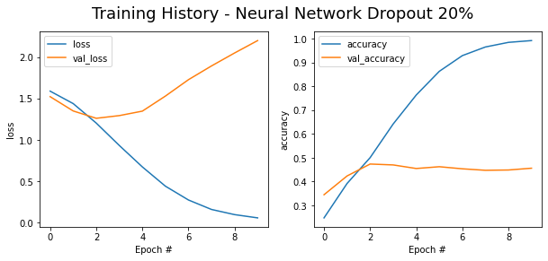

```python
trainingHistoryPlot(model2, 'Training History - Neural Network Dropout 20%')
```

```python
pred_train_labels = np.fromiter(map(lambda x: np.argmax(x), model2.predict(train_sequences)), dtype='float32')
pred_test_labels  = np.fromiter(map(lambda x: np.argmax(x), model2.predict(test_sequences)), dtype='float32')

print('-'*70)
print('Train Data'*1)
print("Accuracy: {:.1f}%".format(
    accuracy_score(train_labels, pred_train_labels)*100
))
#
print('-'*70)
print(classification_report(train_labels + 1, pred_train_labels + 1))
#
print('-'*70)
print('Test Data'*1)
print("Accuracy: {:.1f}%".format(
    accuracy_score(test_labels, pred_test_labels)*100
))
#
print('-'*70)
print(classification_report(test_labels + 1, pred_test_labels + 1))
```

```
----------------------------------------------------------------------
Train Data
Accuracy: 89.0%
----------------------------------------------------------------------
              precision    recall  f1-score   support

         1.0       0.89      0.92      0.90       820
         2.0       0.90      0.87      0.88       780
         3.0       0.89      0.86      0.87       799
         4.0       0.88      0.89      0.88       822
         5.0       0.90      0.92      0.91       779

    accuracy                           0.89      4000
   macro avg       0.89      0.89      0.89      4000
weighted avg       0.89      0.89      0.89      4000

----------------------------------------------------------------------
Test Data
Accuracy: 42.8%
----------------------------------------------------------------------
              precision    recall  f1-score   support

         1.0       0.43      0.52      0.47       180
         2.0       0.40      0.37      0.38       220
         3.0       0.34      0.29      0.32       201
         4.0       0.35      0.37      0.36       178
         5.0       0.58      0.58      0.58       221

    accuracy                           0.43      1000
   macro avg       0.42      0.43      0.42      1000
weighted avg       0.43      0.43      0.43      1000
```

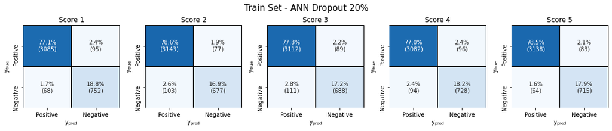

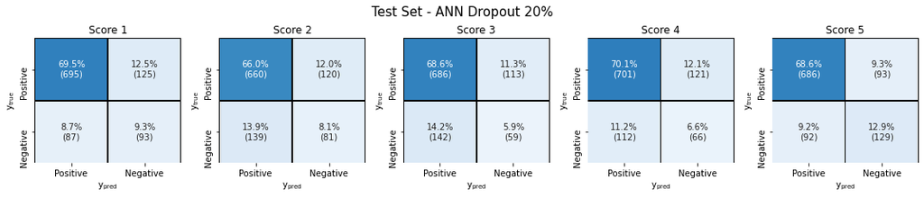

```python
confusion(train_labels, pred_train_labels, 'Train Set - ANN Dropout 20%')
confusion(test_labels,  pred_test_labels,  'Test Set - ANN Dropout 20%')
```

### Exercise 4:

Modify the neural network definition above to try and fix the overfitting problem using Dropout. Explain the configuration that you tried and your results. Why do you think your modifications were or were not able to mitigate the overfitting problem?

**Answer.**

```python
def create_model(dropout=0.0):
  model = Sequential()
  model.add(Embedding(20000, 128, input_length=116))
  model.add(Dropout(dropout))
  model.add(Dense(128, activation='relu'))
  model.add(Dense(128, activation='relu'))
  model.add(GlobalMaxPooling1D())
  model.add(Dense(5, activation='sigmoid'))
  model.compile(loss='sparse_categorical_crossentropy', optimizer='adam', metrics=['accuracy'])
  return model

model_optim = KerasClassifier(build_fn=create_model, verbose=0, validation_split=0.2)
grid_optim  = GridSearchCV(estimator=model_optim, param_grid={'dropout':[0.0, 0.2, 0.4, 0.6, 0.8]})
grid_result = grid_optim.fit(train_sequences, train_labels)
```

```python
model_optim = []
for i in [0.0, 0.2, 0.4, 0.6, 0.8]:
  mod = create_model(i)
  mod.fit(train_sequences, train_labels, validation_split=0.2, epochs=10,
          validation_data=(test_sequences, test_labels))
  model_optim.append(mod.history.history)
```

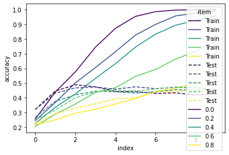

```python
# pd.DataFrame(model_optim)
model_optim_DF = pd.concat([pd.DataFrame(i).assign(item=item) for i, item in zip(model_optim, [0.0, 0.2, 0.4, 0.6, 0.8])])\
.reset_index()

# model_optim_DF['loss']
# model_optim_DF['val_loss']
sns.lineplot(x='index', y='accuracy', hue='item', data=model_optim_DF,     label='Train', ls='-', legend=False, palette='viridis')
sns.lineplot(x='index', y='val_accuracy', hue='item', data=model_optim_DF, label='Test',  ls='--', legend=True, palette='viridis');
```

These results show that the accuracy of the test data is not significantly improved by increased dropout. It is confirmed that the training time has a significant effect on the accuracy of the results.

### Exercise 5:

Keras allows you to add [L1](https://www.tensorflow.org/api_docs/python/tf/keras/regularizers/l1), [L2](https://www.tensorflow.org/api_docs/python/tf/keras/regularizers/l2), or [L1 and L2](https://www.tensorflow.org/api_docs/python/tf/keras/regularizers/l1_l2) combined regularizers on individual layers by passing in the `kernel_regularizer`, `bias_regularizer` or `activity_regularizer` arguments. In neural networks, these regularizers work by penalizing the loss function in different ways, based on the number of weights or the size of the weights.

Try 4-5 different combinations of L1, L2, L1 and L2 regularization in different combinations on different layers. In each example, explain why you tried that configuration and the results. Why do you think your modifications were or were not able to mitigate the overfitting problem?

**Answer.**

### 1. Regularization L1 and L2 in both Dense Layers

```python
def create_model(l1 = 0.01, l2 = 0.01):
  model = Sequential()
  model.add(Embedding(20000, 128, input_length=116))
  model.add(Dropout(0.2))
  model.add(Dense(128, activation='relu',
                  kernel_regularizer = regularizers.l1_l2(l1=l1, l2=l2),
                  bias_regularizer=regularizers.l1_l2(l1=l1, l2=l2),
                  activity_regularizer=regularizers.l1_l2(l1=l1, l2=l2) ))
  model.add(Dense(128, activation='relu',
                  kernel_regularizer = regularizers.l1_l2(l1=l1, l2=l2),
                  bias_regularizer=regularizers.l1_l2(l1=l1, l2=l2),
                  activity_regularizer=regularizers.l1_l2(l1=l1, l2=l2) ))
  model.add(GlobalMaxPooling1D())
  model.add(Dense(5, activation='sigmoid'))
  model.compile(loss='sparse_categorical_crossentropy', optimizer='adam', metrics=['accuracy'])
  return model
```

```python
from tqdm.auto import tqdm
lambda_list = [1e-6, 1e-4, 1e-2]
model_optim_2 = []

for lambda1 in tqdm(lambda_list):
  for lambda2 in tqdm(lambda_list):
    mod = create_model(lambda1, lambda2)
    mod.fit(train_sequences, train_labels, validation_split=0.2, epochs=10, verbose=0,
            validation_data=(test_sequences, test_labels))
    print('Ok iteracion: lambda1 {:.5f} y lambda2 {:.5f}'.format(lambda1, lambda2))
    pred_train_labels = np.fromiter(map(lambda x: np.argmax(x), mod.predict(train_sequences)), dtype='float32')
    pred_test_labels  = np.fromiter(map(lambda x: np.argmax(x), mod.predict(test_sequences)), dtype='float32')
    acc_score_1 = accuracy_score(train_labels, pred_train_labels)
    acc_score_2 = accuracy_score(test_labels, pred_test_labels)

    model_optim_2.append( {'train':acc_score_1, 'test':acc_score_2} )
```

```
Ok iteracion: lambda1 0.00000 y lambda2 0.00000
```

```
Ok iteracion: lambda1 0.00010 y lambda2 0.00000
Ok iteracion: lambda1 0.00010 y lambda2 0.00010
Ok iteracion: lambda1 0.00010 y lambda2 0.01000
```

```
Ok iteracion: lambda1 0.01000 y lambda2 0.00000
Ok iteracion: lambda1 0.01000 y lambda2 0.00010
Ok iteracion: lambda1 0.01000 y lambda2 0.01000
```

```python
model_optim_2_DF = pd.DataFrame(model_optim_2).assign(
    lamb1=[1e-6, 1e-4, 1e-2, 1e-6, 1e-4, 1e-2, 1e-6, 1e-4, 1e-2],
    lamb2 = [1e-6,1e-6,1e-6, 1e-4,1e-4,1e-4, 1e-2,1e-2,1e-2])

# np.min(model_optim_2_DF.loc[:, ['train', 'test']])
model_optim_2_DF
```

|  | train | test | lamb1 | lamb2 |
| --- | --- | --- | --- | --- |
| 0 | 0.88725 | 0.415 | 0.000001 | 0.000001 |
| 1 | 0.88700 | 0.436 | 0.000100 | 0.000001 |
| 2 | 0.20550 | 0.178 | 0.010000 | 0.000001 |
| 3 | 0.63050 | 0.365 | 0.000001 | 0.000100 |
| 4 | 0.54625 | 0.403 | 0.000100 | 0.000100 |
| 5 | 0.20550 | 0.178 | 0.010000 | 0.000100 |
| 6 | 0.20550 | 0.178 | 0.000001 | 0.010000 |
| 7 | 0.20550 | 0.178 | 0.000100 | 0.010000 |
| 8 | 0.20550 | 0.178 | 0.010000 | 0.010000 |

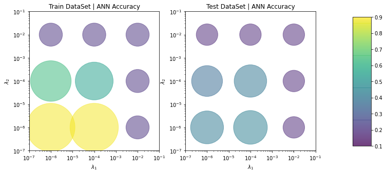

```python
fig, ax = plt.subplots(1,2, figsize=(10,5))
im = ax[0].scatter(model_optim_2_DF.loc[:,'lamb1'], model_optim_2_DF.loc[:,'lamb2'], vmax = 0.9, vmin= 0.1,
              s=model_optim_2_DF.loc[:,'train']*10000, c=model_optim_2_DF.loc[:,'train'], alpha=0.5)
ax[0].set(xscale='log', yscale='log', xlim=(1e-7, 1e-1), ylim=(1e-7, 1e-1),
          xlabel=r'$\lambda_1$', ylabel=r'$\lambda_2$', title='Train DataSet | ANN Accuracy')

im = ax[1].scatter(model_optim_2_DF.loc[:,'lamb1'], model_optim_2_DF.loc[:,'lamb2'], vmax = 0.9, vmin= 0.1,
              s=model_optim_2_DF.loc[:,'test']*10000, c=model_optim_2_DF.loc[:,'test'], alpha=0.5)
ax[1].set(xscale='log', yscale='log', xlim=(1e-7, 1e-1), ylim=(1e-7, 1e-1),
          xlabel=r'$\lambda_1$', ylabel=r'$\lambda_2$', title='Test DataSet | ANN Accuracy')

cbar_ax = fig.add_axes([1.0, 0.15, 0.05, 0.7])
fig.colorbar(im, cax=cbar_ax);
```

```python
model_regul_1 = Sequential()
model_regul_1.add(Embedding(20000, 128, input_length=116))
model_regul_1.add(Dropout(0.2))
model_regul_1.add(Dense(128, activation='relu',
                        kernel_regularizer = regularizers.l1_l2(l1=1e-6, l2=1e-6),
                        bias_regularizer=regularizers.l1_l2(l1=1e-6, l2=1e-6),
                        activity_regularizer=regularizers.l1_l2(l1=1e-6, l2=1e-6) ))
model_regul_1.add(Dense(128, activation='relu',
                        kernel_regularizer = regularizers.l1_l2(l1=1e-6, l2=1e-6),
                        bias_regularizer=regularizers.l1_l2(l1=1e-6, l2=1e-6),
                        activity_regularizer=regularizers.l1_l2(l1=1e-6, l2=1e-6) ))
model_regul_1.add(GlobalMaxPooling1D())
model_regul_1.add(Dense(5, activation='sigmoid'))
model_regul_1.compile(loss='sparse_categorical_crossentropy', optimizer='adam', metrics=['accuracy'])
model_regul_1.fit(train_sequences, train_labels, validation_split=0.2, epochs=10,
                  validation_data=(test_sequences, test_labels))
```

```
<tensorflow.python.keras.callbacks.History at 0x7fb7516935f8>
```

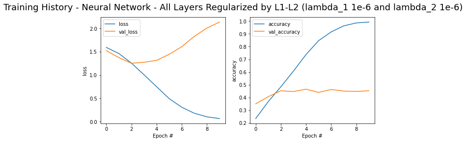

```python
trainingHistoryPlot(model_regul_1, 'Training History - Neural Network - All Layers Regularized by L1-L2 (lambda_1 1e-6 and lambda_2 1e-6)')
fig.set_tight_layout(True)
```

```python
pred_train_labels = np.fromiter(map(lambda x: np.argmax(x), model_regul_1.predict(train_sequences)), dtype='float32')
pred_test_labels  = np.fromiter(map(lambda x: np.argmax(x), model_regul_1.predict(test_sequences)), dtype='float32')

print('-'*70)
print('Train Data'*1)
print("Accuracy: {:.1f}%".format(
    accuracy_score(train_labels, pred_train_labels)*100
))
#
print('-'*70)
print(classification_report(train_labels + 1, pred_train_labels + 1))
#
print('-'*70)
print('Test Data'*1)
print("Accuracy: {:.1f}%".format(
    accuracy_score(test_labels, pred_test_labels)*100
))
#
print('-'*70)
print(classification_report(test_labels + 1, pred_test_labels + 1))
```

```
----------------------------------------------------------------------
Train Data
Accuracy: 88.9%
----------------------------------------------------------------------
              precision    recall  f1-score   support

         1.0       0.90      0.90      0.90       820
         2.0       0.86      0.88      0.87       780
         3.0       0.90      0.86      0.88       799
         4.0       0.87      0.89      0.88       822
         5.0       0.92      0.92      0.92       779

    accuracy                           0.89      4000
   macro avg       0.89      0.89      0.89      4000
weighted avg       0.89      0.89      0.89      4000

----------------------------------------------------------------------
Test Data
Accuracy: 45.3%
----------------------------------------------------------------------
              precision    recall  f1-score   support

         1.0       0.51      0.54      0.52       180
         2.0       0.45      0.38      0.41       220
         3.0       0.36      0.33      0.35       201
         4.0       0.34      0.43      0.38       178
         5.0       0.60      0.58      0.59       221

    accuracy                           0.45      1000
   macro avg       0.45      0.45      0.45      1000
weighted avg       0.46      0.45      0.45      1000
```

### 2. Regularization L2 in both Dense Layers

```python
def create_model(l2 = 0.01):
  model = Sequential()
  model.add(Embedding(20000, 128, input_length=116))
  model.add(Dropout(0.2))
  model.add(Dense(128, activation='relu',
                  kernel_regularizer = regularizers.l2(l2),
                  bias_regularizer=regularizers.l2(l2),
                  activity_regularizer=regularizers.l2(l2) ))
  model.add(Dense(128, activation='relu',
                  kernel_regularizer = regularizers.l2(l2),
                  bias_regularizer=regularizers.l2(l2),
                  activity_regularizer=regularizers.l2(l2) ))
  model.add(GlobalMaxPooling1D())
  model.add(Dense(5, activation='sigmoid'))
  model.compile(loss='sparse_categorical_crossentropy', optimizer='adam', metrics=['accuracy'])
  return model
```

```python
from tqdm.auto import tqdm
lambda_list = [1e-8, 1e-7, 1e-6, 1e-5, 1e-4, 1e-3, 1e-2]
model_optim_3 = []

for lambda2 in tqdm(lambda_list):
  mod = create_model(lambda2)
  mod.fit(train_sequences, train_labels, validation_split=0.2, epochs=10, verbose=0,
          validation_data=(test_sequences, test_labels))
  print('Ok iteracion: lambda2 {:.5f}'.format(lambda2))
  pred_train_labels = np.fromiter(map(lambda x: np.argmax(x), mod.predict(train_sequences)), dtype='float32')
  pred_test_labels  = np.fromiter(map(lambda x: np.argmax(x), mod.predict(test_sequences)), dtype='float32')
  acc_score_1 = accuracy_score(train_labels, pred_train_labels)
  acc_score_2 = accuracy_score(test_labels, pred_test_labels)

  model_optim_3.append( {'train':acc_score_1, 'test':acc_score_2} )
```

```
Ok iteracion: lambda2 0.00000
Ok iteracion: lambda2 0.00000
Ok iteracion: lambda2 0.00000
Ok iteracion: lambda2 0.00001
Ok iteracion: lambda2 0.00010
Ok iteracion: lambda2 0.00100
Ok iteracion: lambda2 0.01000
```

```python
model_optim_3_DF = pd.DataFrame(model_optim_3).assign(lamb2 = lambda_list)
model_optim_3_DF
```

|  | train | test | lamb2 |
| --- | --- | --- | --- |
| 0 | 0.89075 | 0.443 | 1.000000e-08 |
| 1 | 0.88425 | 0.424 | 1.000000e-07 |
| 2 | 0.88825 | 0.432 | 1.000000e-06 |
| 3 | 0.89000 | 0.437 | 1.000000e-05 |
| 4 | 0.88475 | 0.438 | 1.000000e-04 |
| 5 | 0.66550 | 0.361 | 1.000000e-03 |
| 6 | 0.20550 | 0.178 | 1.000000e-02 |

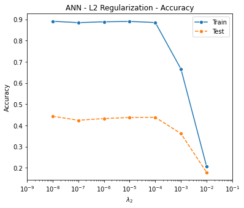

```python
fig, ax = plt.subplots(figsize=(6,5))
sns.lineplot(x='lamb2', y='train', data=model_optim_3_DF, label='Train', ax=ax, marker='o', ls='-')
sns.lineplot(x='lamb2', y='test',  data=model_optim_3_DF, label='Test', ax=ax,  marker='o', ls='--')
ax.set(xscale='log', xlim=(1e-9, 1e-1),
       xlabel=r'$\lambda_2$', ylabel='Accuracy', title='ANN - L2 Regularization - Accuracy');
```

For the reasons mentioned above, it is decided to use a value $\lambda_{2} $ of $10^{- 4} $ to prevent a bad behavior of the model, below we can see in more detail the behavior of this model.

```python
model_regul_2 = Sequential()
model_regul_2.add(Embedding(20000, 128, input_length=116))
model_regul_2.add(Dropout(0.2))
model_regul_2.add(Dense(128, activation='relu',
                        kernel_regularizer = regularizers.l2(1e-4),
                        bias_regularizer=regularizers.l2(1e-4),
                        activity_regularizer=regularizers.l2(1e-4) ))
model_regul_2.add(Dense(128, activation='relu',
                        kernel_regularizer = regularizers.l2(1e-4),
                        bias_regularizer=regularizers.l2(1e-4),
                        activity_regularizer=regularizers.l2(1e-4) ))
model_regul_2.add(GlobalMaxPooling1D())
model_regul_2.add(Dense(5, activation='sigmoid'))
model_regul_2.compile(loss='sparse_categorical_crossentropy', optimizer='adam', metrics=['accuracy'])
model_regul_2.fit(train_sequences, train_labels, validation_split=0.2, epochs=10,
                  validation_data=(test_sequences, test_labels))
```

```
<tensorflow.python.keras.callbacks.History at 0x7fb75057ec18>
```

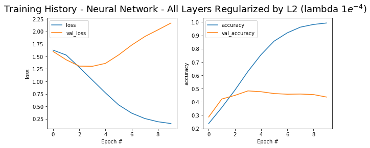

```python
trainingHistoryPlot(model_regul_2, r'Training History - Neural Network - All Layers Regularized by L2 (lambda $1e^{-4}$)')
fig.set_tight_layout(True)
```

```python
pred_train_labels = np.fromiter(map(lambda x: np.argmax(x), model_regul_2.predict(train_sequences)), dtype='float32')
pred_test_labels  = np.fromiter(map(lambda x: np.argmax(x), model_regul_2.predict(test_sequences)), dtype='float32')

print('-'*70)
print('Train Data'*1)
print("Accuracy: {:.1f}%".format(
    accuracy_score(train_labels, pred_train_labels)*100
))
#
print('-'*70)
print(classification_report(train_labels + 1, pred_train_labels + 1))
#
print('-'*70)
print('Test Data'*1)
print("Accuracy: {:.1f}%".format(
    accuracy_score(test_labels, pred_test_labels)*100
))
#
print('-'*70)
print(classification_report(test_labels + 1, pred_test_labels + 1))
```

```
----------------------------------------------------------------------
Train Data
Accuracy: 88.6%
----------------------------------------------------------------------
              precision    recall  f1-score   support

         1.0       0.91      0.89      0.90       820
         2.0       0.86      0.87      0.86       780
         3.0       0.88      0.86      0.87       799
         4.0       0.86      0.89      0.88       822
         5.0       0.92      0.91      0.91       779

    accuracy                           0.89      4000
   macro avg       0.89      0.89      0.89      4000
weighted avg       0.89      0.89      0.89      4000

----------------------------------------------------------------------
Test Data
Accuracy: 42.5%
----------------------------------------------------------------------
              precision    recall  f1-score   support

         1.0       0.52      0.52      0.52       180
         2.0       0.36      0.39      0.38       220
         3.0       0.33      0.31      0.32       201
         4.0       0.32      0.38      0.35       178
         5.0       0.62      0.52      0.57       221

    accuracy                           0.42      1000
   macro avg       0.43      0.42      0.43      1000
weighted avg       0.43      0.42      0.43      1000
```

The precision behavior of the model with L2 regularization is similar to the model with L1-L2 regularization.

### 3. Best sub component to regularize each layer

```python
def create_model(inKernel = False, inBias=False, inActivity=False, l2=1e-4):
  model = Sequential()
  model.add(Embedding(20000, 128, input_length=116))
  model.add(Dropout(0.2))

  if inKernel is False: kernelRegularizer = 'None';
  else: kernelRegularizer = 'regularizers.l2(l2)'
  if inBias is False: biasRegularizer = 'None'
  else: biasRegularizer = 'regularizers.l2(l2)'
  if inActivity is False: activityRegularizer = 'None'
  else: activityRegularizer = 'regularizers.l2(l2)'

  model.add(Dense(128, activation='relu',
                  kernel_regularizer   = eval(kernelRegularizer),
                  bias_regularizer     = eval(biasRegularizer),
                  activity_regularizer = eval(activityRegularizer) ))
  model.add(Dense(128, activation='relu',
                  kernel_regularizer   = eval(kernelRegularizer),
                  bias_regularizer     = eval(biasRegularizer),
                  activity_regularizer = eval(activityRegularizer) ))
  model.add(GlobalMaxPooling1D())
  model.add(Dense(5, activation='sigmoid'))
  model.compile(loss='sparse_categorical_crossentropy', optimizer='adam', metrics=['accuracy'])

  return model
```

```python
from itertools import product

def expand_grid(dict):
   return pd.DataFrame([row for row in product(*dict.values())], columns=dict.keys())

regularizeType = expand_grid({'inKernel':[True, False], 'inBias':[True, False], 'inActivity':[True,False]})
regularizeType
```

|  | inKernel | inBias | inActivity |
| --- | --- | --- | --- |
| 0 | True | True | True |
| 1 | True | True | False |
| 2 | True | False | True |
| 3 | True | False | False |
| 4 | False | True | True |
| 5 | False | True | False |
| 6 | False | False | True |
| 7 | False | False | False |

```python
from tqdm.auto import tqdm
model_optim_4 = []
for i in tqdm(regularizeType.iterrows()):
  mod = create_model( i[1][0], i[1][1], i[1][2] )
  mod.fit(train_sequences, train_labels, validation_split=0.2, epochs=10, verbose=0,
          validation_data=(test_sequences, test_labels))
  print('Ok iteracion: inKernel {m}, inBias {n}, inActivity {o}'.format(m= i[1][0], n=i[1][1], o =i[1][2] ))
  pred_train_labels = np.fromiter(map(lambda x: np.argmax(x), mod.predict(train_sequences)), dtype='float32')
  pred_test_labels  = np.fromiter(map(lambda x: np.argmax(x), mod.predict(test_sequences)), dtype='float32')
  acc_score_1 = accuracy_score(train_labels, pred_train_labels)
  acc_score_2 = accuracy_score(test_labels, pred_test_labels)
  model_optim_4.append( {'train':acc_score_1, 'test':acc_score_2} )
```

```
Ok iteracion: inKernel True, inBias True, inActivity True
Ok iteracion: inKernel True, inBias True, inActivity False
Ok iteracion: inKernel True, inBias False, inActivity True
Ok iteracion: inKernel True, inBias False, inActivity False
Ok iteracion: inKernel False, inBias True, inActivity True
Ok iteracion: inKernel False, inBias True, inActivity False
Ok iteracion: inKernel False, inBias False, inActivity True
Ok iteracion: inKernel False, inBias False, inActivity False
```

```python
model_optim_4_DF = pd.concat([regularizeType, pd.DataFrame(model_optim_4)], axis=1)\
.replace({'inKernel'   : {True:1, False:0},
          'inBias'     : {True:1, False:0},
          'inActivity' : {True:1, False:0}})

model_optim_4_DF
```

|  | inKernel | inBias | inActivity | train | test |
| --- | --- | --- | --- | --- | --- |
| 0 | 1 | 1 | 1 | 0.88450 | 0.412 |
| 1 | 1 | 1 | 0 | 0.88275 | 0.430 |
| 2 | 1 | 0 | 1 | 0.88575 | 0.421 |
| 3 | 1 | 0 | 0 | 0.88900 | 0.429 |
| 4 | 0 | 1 | 1 | 0.88550 | 0.447 |
| 5 | 0 | 1 | 0 | 0.88350 | 0.434 |
| 6 | 0 | 0 | 1 | 0.88675 | 0.417 |
| 7 | 0 | 0 | 0 | 0.88775 | 0.435 |

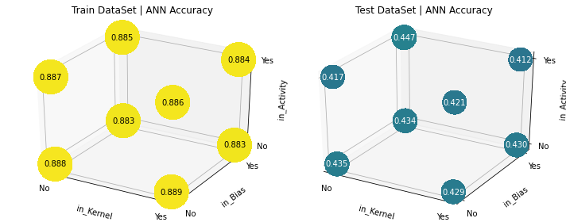

```python
fig = plt.figure(figsize=(10,4))

ax1 = fig.add_subplot(121, projection='3d')
ax2 = fig.add_subplot(122, projection='3d')

ax1.scatter(model_optim_4_DF.loc[:, 'inKernel'], model_optim_4_DF.loc[:, 'inBias'], model_optim_4_DF.loc[:, 'inActivity'],
           c=model_optim_4_DF.loc[:, 'train'], s = model_optim_4_DF.loc[:, 'train']*2000,
            vmax = 0.9, vmin= 0.1, antialiased=False, alpha=1, marker='o' );

for text_i in model_optim_4_DF.iterrows():
  label = '{:.3f}'.format(text_i[1][3])
  ax1.text(text_i[1][0], text_i[1][1], text_i[1][2], label, va='center', ha='center')

ax2.scatter(model_optim_4_DF.loc[:, 'inKernel'], model_optim_4_DF.loc[:, 'inBias'], model_optim_4_DF.loc[:, 'inActivity'],
           c=model_optim_4_DF.loc[:, 'test'], s = model_optim_4_DF.loc[:, 'test']*2000,
           vmax = 0.9, vmin= 0.1, antialiased=False, alpha=1, marker='o' );

for text_i in model_optim_4_DF.iterrows():
  label = '{:.3f}'.format(text_i[1][4])
  ax2.text(text_i[1][0], text_i[1][1], text_i[1][2], label, va='center', ha='center', color='w')

ax1.set(xlabel='in_Kernel', ylabel='in_Bias', zlabel='in_Activity', title='Train DataSet | ANN Accuracy\n')
ax2.set(xlabel='in_Kernel', ylabel='in_Bias', zlabel='in_Activity', title='Test DataSet | ANN Accuracy\n')
#
ax1.set(xticks=[1,0], yticks=[1,0], zticks=[1,0], xticklabels=['Yes', 'No'], yticklabels=['Yes', 'No'], zticklabels=['Yes', 'No'])
ax2.set(xticks=[1,0], yticks=[1,0], zticks=[1,0], xticklabels=['Yes', 'No'], yticklabels=['Yes', 'No'], zticklabels=['Yes', 'No'])
fig.set_tight_layout(True);
```

```python
model_regul_3 = create_model(inKernel=True, inBias=False, inActivity=True, l2=1e-4)

model_regul_3.fit(train_sequences, train_labels, validation_split=0.2, epochs=10,
                  validation_data=(test_sequences, test_labels))
```

```
<tensorflow.python.keras.callbacks.History at 0x7fb73df4ba58>
```

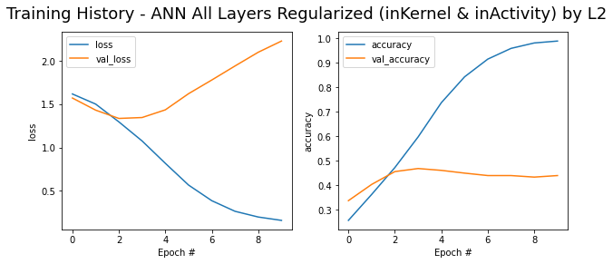

```python
trainingHistoryPlot(model_regul_3, 'Training History - ANN All Layers Regularized (inKernel & inActivity) by L2')
fig.set_tight_layout(True)
```

```python
def create_model(both_layers = [True, True], inKernel = False, inBias=False, inActivity=False, l2=1e-4):
  model = Sequential()
  model.add(Embedding(20000, 128, input_length=116))
  model.add(Dropout(0.2))

  if inKernel is False: kernelRegularizer = 'None';
  else: kernelRegularizer = 'regularizers.l2(l2)'
  if inBias is False: biasRegularizer = 'None'
  else: biasRegularizer = 'regularizers.l2(l2)'
  if inActivity is False: activityRegularizer = 'None'
  else: activityRegularizer = 'regularizers.l2(l2)'

  if both_layers[0] is True:
    model.add(Dense(128, activation='relu',
                  kernel_regularizer   = eval(kernelRegularizer),
                  bias_regularizer     = eval(biasRegularizer),
                  activity_regularizer = eval(activityRegularizer) ))
  else:
    model.add(Dense(128, activation='relu'))

  if both_layers[1] is True:
    model.add(Dense(128, activation='relu',
                  kernel_regularizer   = eval(kernelRegularizer),
                  bias_regularizer     = eval(biasRegularizer),
                  activity_regularizer = eval(activityRegularizer) ))
  else:
    model.add(Dense(128, activation='relu'))

  model.add(GlobalMaxPooling1D())
  model.add(Dense(5, activation='sigmoid'))
  model.compile(loss='sparse_categorical_crossentropy', optimizer='adam', metrics=['accuracy'])

  return model
```

```python
bothLayers = expand_grid({'Layer_1':[True, False], 'Layer_2':[True, False]})
bothLayers
```

|  | Layer_1 | Layer_2 |
| --- | --- | --- |
| 0 | True | True |
| 1 | True | False |
| 2 | False | True |
| 3 | False | False |

```python
from tqdm.auto import tqdm

model_optim_5 = []
for i in tqdm(bothLayers.iterrows()):
  mod = create_model([i[1][0], i[1][1]], inKernel=True, inBias=False, inActivity=True, l2=1e-4)
  mod.fit(train_sequences, train_labels, validation_split=0.2, epochs=10, verbose=0,
          validation_data=(test_sequences, test_labels))
  print('Ok iteracion: Regul. Layer 1 {m} - Regul. Layer 2 {n}'.format(m= i[1][0], n= i[1][1]))
  pred_train_labels = np.fromiter(map(lambda x: np.argmax(x), mod.predict(train_sequences)), dtype='float32')
  pred_test_labels  = np.fromiter(map(lambda x: np.argmax(x), mod.predict(test_sequences)), dtype='float32')
  acc_score_1 = accuracy_score(train_labels, pred_train_labels)
  acc_score_2 = accuracy_score(test_labels, pred_test_labels)
  model_optim_5.append( {'train':acc_score_1, 'test':acc_score_2} )
```

```
Ok iteracion: Regul. Layer 1 True - Regul. Layer 2 True
Ok iteracion: Regul. Layer 1 True - Regul. Layer 2 False
Ok iteracion: Regul. Layer 1 False - Regul. Layer 2 True
Ok iteracion: Regul. Layer 1 False - Regul. Layer 2 False
```

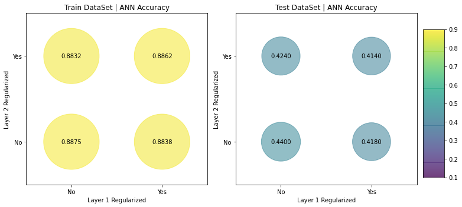

```python
bothLayers_DF = pd.concat([bothLayers, pd.DataFrame(model_optim_5)], axis=1)
bothLayers_DF


fig, ax = plt.subplots(1,2, figsize=(10,5))
im = ax[0].scatter(bothLayers_DF.loc[:,'Layer_1'], bothLayers_DF.loc[:,'Layer_2'], vmax = 0.9, vmin= 0.1,
                   s = bothLayers_DF.loc[:,'train']*10000, c = bothLayers_DF.loc[:,'train'], alpha=0.5)
ax[0].set(xlim=(-0.5, 1.5), ylim=(-0.5, 1.5), xticks=[1, 0], xticklabels=['Yes', 'No'], yticks=[1, 0], yticklabels=['Yes', 'No'],
          xlabel= 'Layer 1 Regularized', ylabel= 'Layer 2 Regularized', title='Train DataSet | ANN Accuracy')

for text_i in bothLayers_DF.iterrows():
  label = '{:.4f}'.format(text_i[1][2])
  ax[0].text(text_i[1][0], text_i[1][1], label, va='center', ha='center')

im = ax[1].scatter(bothLayers_DF.loc[:,'Layer_1'], bothLayers_DF.loc[:,'Layer_2'], vmax = 0.9, vmin= 0.1,
                   s = bothLayers_DF.loc[:,'test']*10000, c = bothLayers_DF.loc[:,'test'], alpha=0.5)
ax[1].set(xlim=(-0.5, 1.5), ylim=(-0.5, 1.5), xticks=[1, 0], xticklabels=['Yes', 'No'], yticks=[1, 0], yticklabels=['Yes', 'No'],
          xlabel= 'Layer 1 Regularized', ylabel= 'Layer 2 Regularized', title='Test DataSet | ANN Accuracy')

for text_i in bothLayers_DF.iterrows():
  label = '{:.4f}'.format(text_i[1][3])
  ax[1].text(text_i[1][0], text_i[1][1], label, va='center', ha='center')

cbar_ax = fig.add_axes([1.0, 0.15, 0.05, 0.7])
fig.colorbar(im, cax=cbar_ax)
fig.set_tight_layout(True);
```

This result suggests that regularization should not be used in the deep layers of the neural network, because the base model shows better precision for the training and validation data.